# Diamonds Price Prediction

Diamonds take billions of years to form and not all of them survive the long journey. This project aims to estimate the effects on diamond prices. We run regressions using the diamonds dataset, consisting of 53,940 round diamonds and ten variables. The final model use carat, color, and clarity as variables to estimate their causality on diamond price. The model goodness of fit is evaluated by R-Squared of 0.903.

# Data Description

| variable | Type | Detail |
| --- | --- | --- |
| price | Numeric | Price in US dollars |
| carat | Numeric | Weight of the diamond |
| cut | Ordinal | Quality of the cut (Fair, Good, Very Good, Premium, Ideal) |
| color | Ordinal | Diamond color, from D (best) to J (worst) |
| clarity | Ordinal | A measurement of how clear the diamond is (I1 (worst), SI2, SI1, VS2, VS1, VVS2, VVS1, IF (best)) |
| x | Numeric | Length in mm |
| y | Numeric | Width in mm |
| z | Numeric | Depth in mm |
| depth | Numeric | Total depth percentage |
| table | Numeric | Width of top of diamond relative to widest point |

Let’s look at the diamonds dataset from the R package. We do not need to separately download the raw data file because the data is available in `Ggplot2`, a subset of the `Tidyverse` package. If you want to import the data file into R, you can use the `read_csv` function in the comment below. Then, we can use the `glimpse` function to look at the raw data.

```r
#diamonds <- read_csv(here::here("data", "diamonds.csv"))
glimpse(diamonds)
```

```
Rows: 53,940
Columns: 10
$ carat   <dbl> 0.23, 0.21, 0.23, 0.29, 0.31, 0.24, 0.24, 0.26, 0.22…
$ cut     <ord> Ideal, Premium, Good, Premium, Good, Very Good, Very…
$ color   <ord> E, E, E, I, J, J, I, H, E, H, J, J, F, J, E, E, I, J…
$ clarity <ord> SI2, SI1, VS1, VS2, SI2, VVS2, VVS1, SI1, VS2, VS1, …
$ depth   <dbl> 61.5, 59.8, 56.9, 62.4, 63.3, 62.8, 62.3, 61.9, 65.1…
$ table   <dbl> 55, 61, 65, 58, 58, 57, 57, 55, 61, 61, 55, 56, 61, …
$ price   <int> 326, 326, 327, 334, 335, 336, 336, 337, 337, 338, 33…
$ x       <dbl> 3.95, 3.89, 4.05, 4.20, 4.34, 3.94, 3.95, 4.07, 3.87…
$ y       <dbl> 3.98, 3.84, 4.07, 4.23, 4.35, 3.96, 3.98, 4.11, 3.78…
$ z       <dbl> 2.43, 2.31, 2.31, 2.63, 2.75, 2.48, 2.47, 2.53, 2.49…
```

# Data cleaning and preparation

The diamonds data requires small cleaning because it is very clean and well organized. As I will run regression models, I have decided to convert the three ordinal variables to numeric scales. I also assume that the scale for color and clarity variables is equally scaled across the levels. In addition, I remove observation with value zero in x, y and z variables because it does not make sense if the dimension is zero. The dataset now has 53,920 samples and ten variables.

```r
# use plyr::revalue to convert cut, color, and clarity scales to number
data <- diamonds
data$color <- as.numeric(revalue(data$color, c("D"=1, "E"=2, "F"=3, "G"=4, "H"=5, "I"=6, "J"=7)))
data$clarity <- as.numeric(revalue(data$clarity, c("IF"=8, "VVS1"=7, "VVS2"=6, "VS1"=5, "VS2"=4, "SI1"=3, "SI2"=2, "I1"=1)))
data$cut <- as.numeric(revalue(data$cut, c("Fair"=1, "Good"=2, "Very Good"=3, "Premium"=4, "Ideal"=5)))

data <- data %>%
  filter(x>0, y>0, z>0)

#describe(data, ranges = FALSE)
summary(data)
```

```
     carat             cut            color          clarity
 Min.   :0.2000   Min.   :1.000   Min.   :1.000   Min.   :1.000
 1st Qu.:0.4000   1st Qu.:3.000   1st Qu.:2.000   1st Qu.:3.000
 Median :0.7000   Median :4.000   Median :4.000   Median :4.000
 Mean   :0.7977   Mean   :3.904   Mean   :3.594   Mean   :4.052
 3rd Qu.:1.0400   3rd Qu.:5.000   3rd Qu.:5.000   3rd Qu.:5.000
 Max.   :5.0100   Max.   :5.000   Max.   :7.000   Max.   :8.000
     depth           table           price             x
 Min.   :43.00   Min.   :43.00   Min.   :  326   Min.   : 3.730
 1st Qu.:61.00   1st Qu.:56.00   1st Qu.:  949   1st Qu.: 4.710
 Median :61.80   Median :57.00   Median : 2401   Median : 5.700
 Mean   :61.75   Mean   :57.46   Mean   : 3931   Mean   : 5.732
 3rd Qu.:62.50   3rd Qu.:59.00   3rd Qu.: 5323   3rd Qu.: 6.540
 Max.   :79.00   Max.   :95.00   Max.   :18823   Max.   :10.740
       y                z
 Min.   : 3.680   Min.   : 1.07
 1st Qu.: 4.720   1st Qu.: 2.91
 Median : 5.710   Median : 3.53
 Mean   : 5.735   Mean   : 3.54
 3rd Qu.: 6.540   3rd Qu.: 4.04
 Max.   :58.900   Max.   :31.80
```

## Distribution and normality of each variable

In this section, we will explore the distribution and normality using the `plot_normality()` function in the `Dlookr` package. The function provides normality diagnosis of each variable, including distribution of the original data (upper left), Q-Q plot (upper right), and transformation using log and square root (bottom).

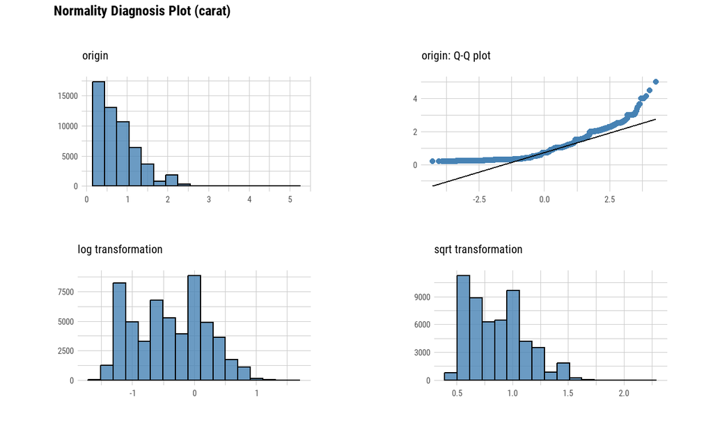

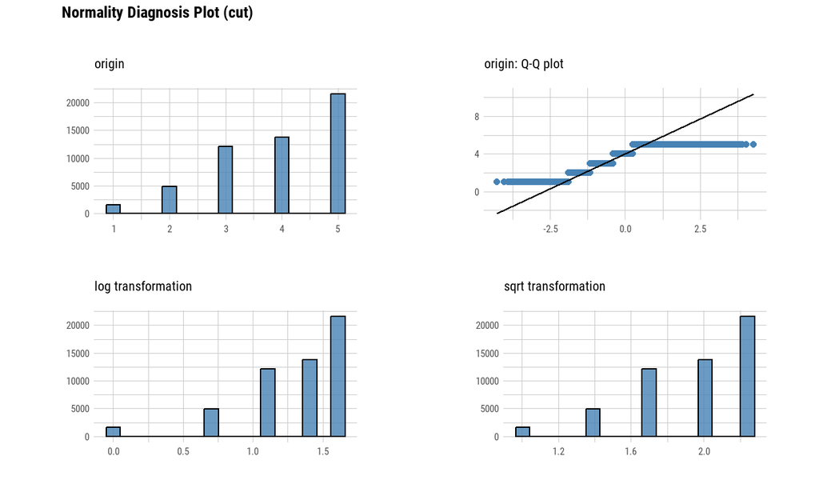

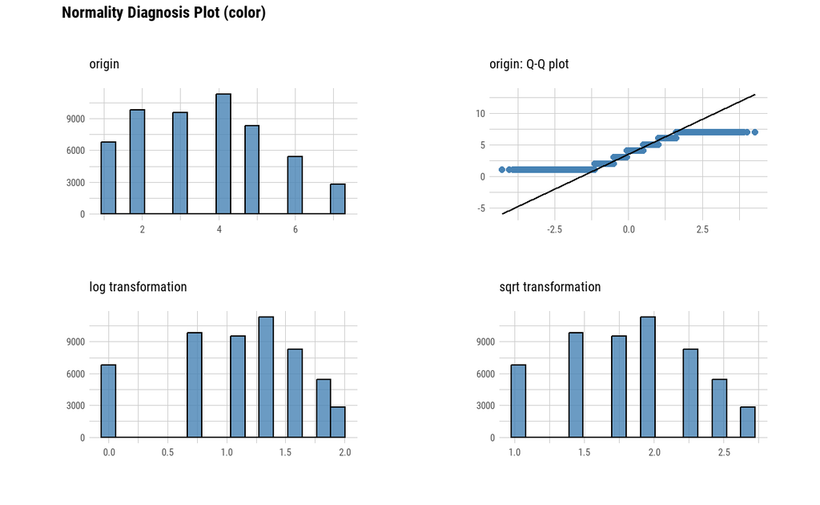

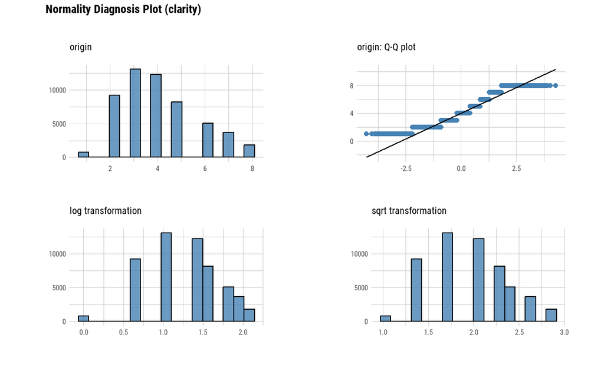

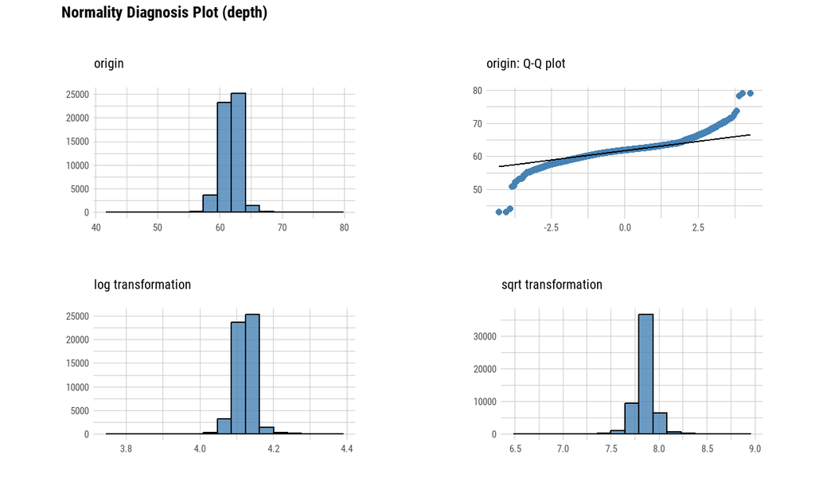

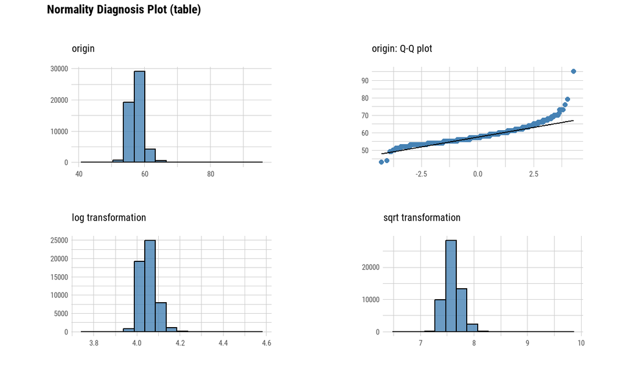

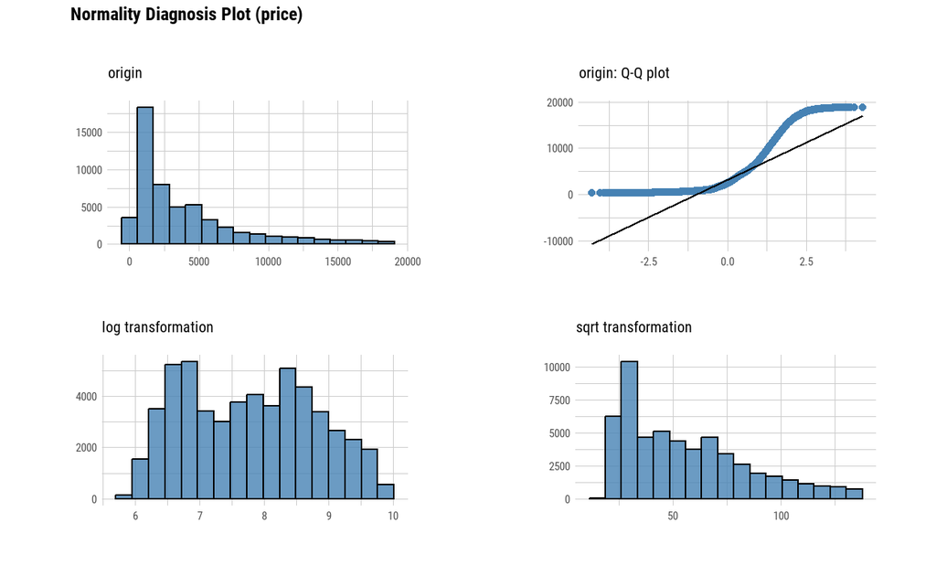

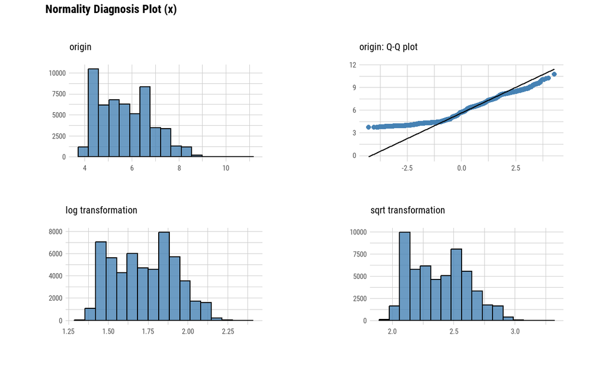

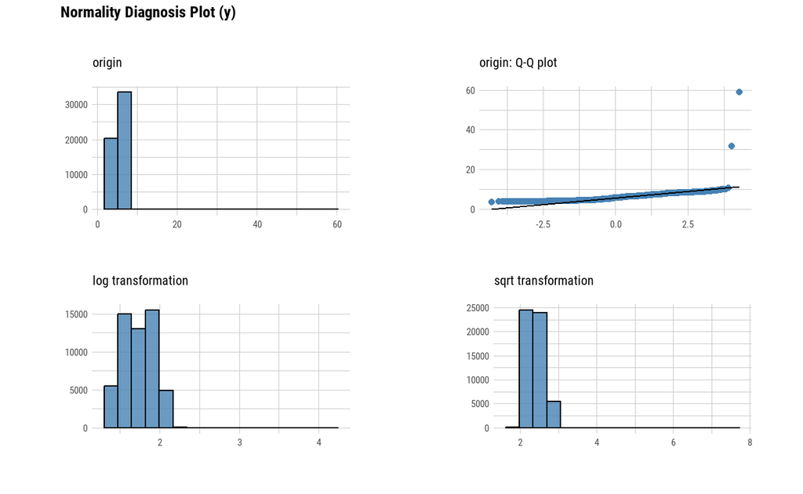

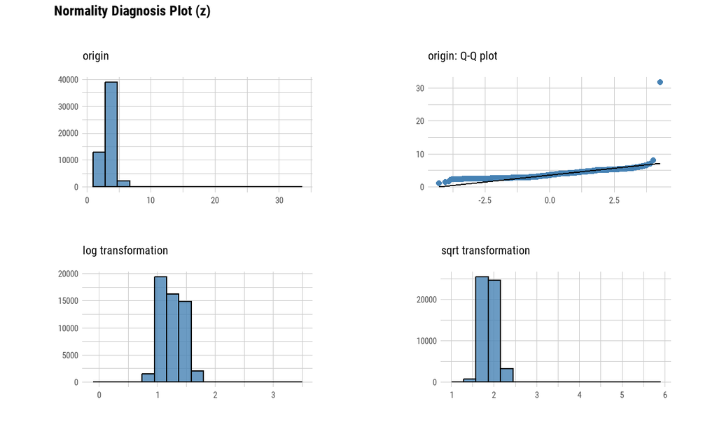

```r
dlookr::plot_normality(data)
```

# Exploratory Data Analysis (EDA)

**Pie chart of the Diamond Cut**

The pie chart shows the diamond cut ratio. Overall, the diamond quality cut was excellent, with 40 percent accounting for ideal quality, 26 percent for premium quality, 22 percent for very good quality, 3 percent was fair quality.

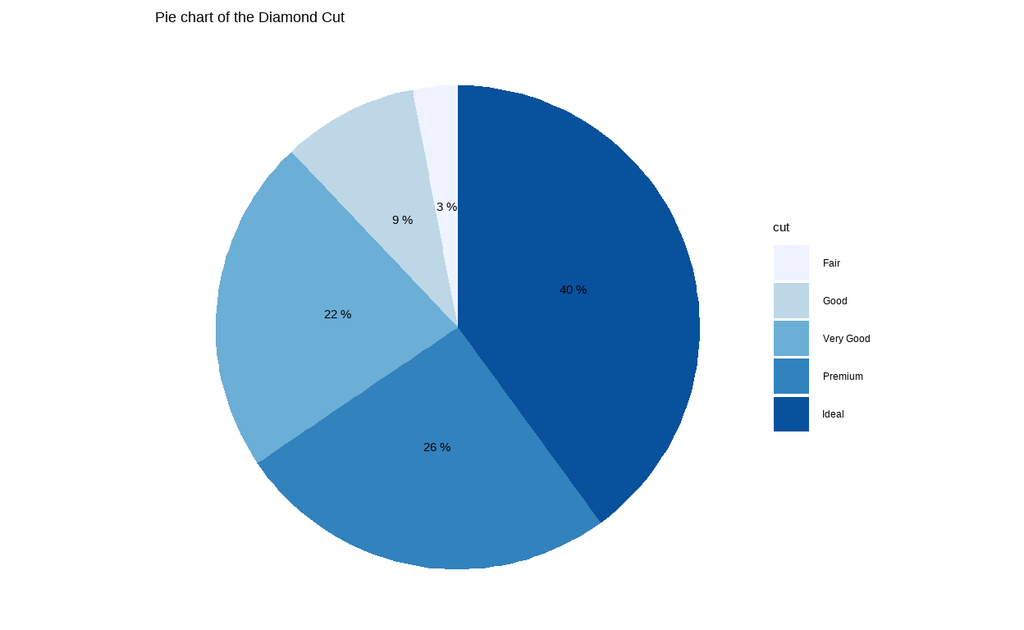

```r
diamonds%>%
  filter(x>0, y>0, z>0)%>%
  group_by(cut)%>%
  dplyr::summarise(count=n())%>%
  mutate(percent_data=paste(as.character(round(count*100/53920),2),"%"))%>%
  ggplot(aes(x="",y=count, fill=cut))+
  geom_bar(stat="identity", width=1)+
  coord_polar("y", start=0)+
  scale_fill_brewer(palette="Blues")+
  geom_text(aes(label = percent_data),
            position = position_stack(vjust = 0.5))+
  theme_void()+
  labs(title = "Pie chart of the Diamond Cut")
```

**Diamond Frequency by Color**

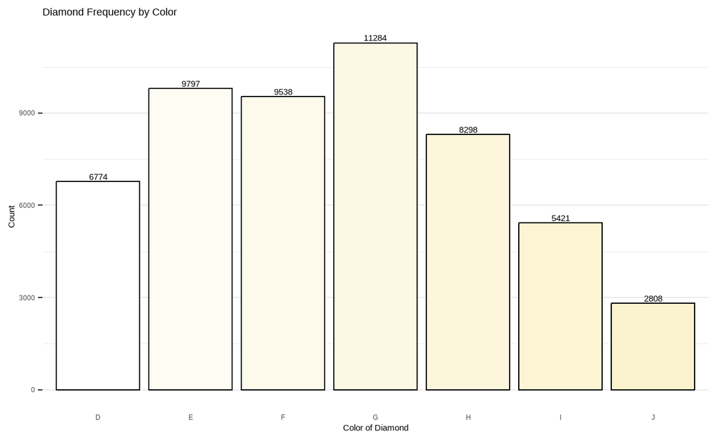

```r
diamonds%>%
  filter(x>0, y>0, z>0)%>%
  group_by(color)%>%
  dplyr::summarise(count=n())%>%
  ggplot(aes(x=color,count,y=count, fill=color))+
  geom_bar(stat="identity", colour="black")+
  scale_fill_manual(values=c("#ffffff", "#fefcf3", "#fdfaeb", "#fdf8e4", "#fcf6dc", "#fcf5d4", "#fbf3cd"))+
  labs(title = "Diamond Frequency by Color", x="Color of Diamond", y="Count")+
  theme_bw()+
  theme(legend.position = "none",
    panel.grid.major.x = element_blank(),
    panel.border = element_blank(),
    axis.ticks.x = element_blank())+
  geom_text(aes(label = count, vjust = -0.4))
```

**Diamond Frequency by Clarity Level**

The lollipop chart presents the data frequency by clarity color. Most diamonds are slightly included, such as VS2, SI1, and SI2 levels. There are 1,790 internally flawless diamonds. The included diamond is the smallest at only 738 observations.

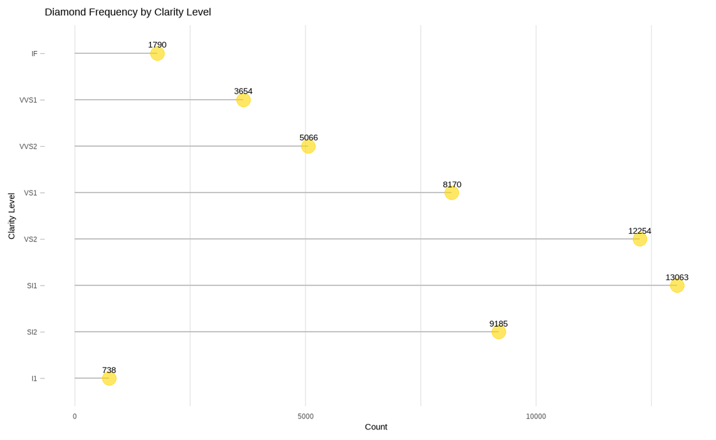

```r
diamonds%>%
  filter(x>0, y>0, z>0)%>%
  group_by(clarity)%>%
  dplyr::summarise(count=n())%>%
  ggplot(aes(x=clarity, y=count))+
  geom_segment( aes(x=clarity, xend=clarity, y=0, yend=count), color="grey")+
  geom_point( color="gold", size=4, alpha=0.6)+
  theme_light()+
  coord_flip()+
  labs(title="Diamond Frequency by Clarity Level", x="Clarity Level", y="Count")+
  theme(
    panel.grid.major.y = element_blank(),
    panel.border = element_blank(),
    axis.ticks.x = element_blank())+
    geom_text(aes(label = count, vjust = -1))
```

## Diamond Price, Carat, and Cut

Let’s explore more about the relations between price, carat, and cut. The scatter plot shows that the better cut quality with the same carat has a higher price.

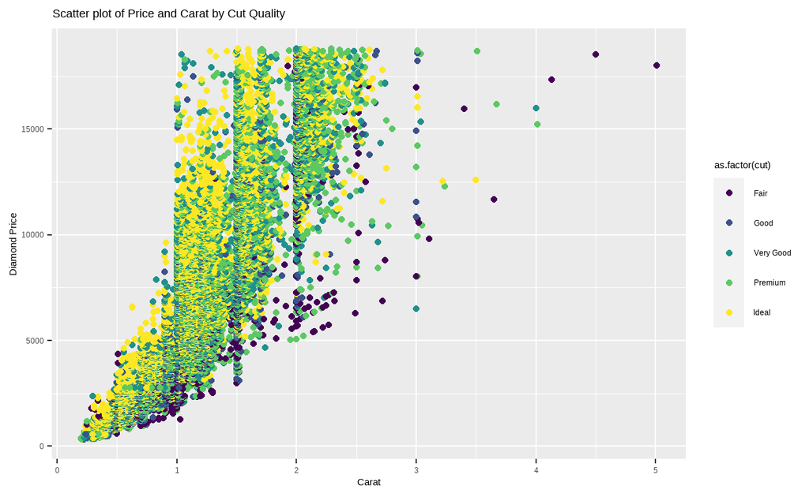

```r
diamonds%>%
  filter(x>0, y>0, z>0)%>%
  ggplot(aes(carat, price, colour = as.factor(cut))) + geom_point()+
  labs(title = "Scatter plot of Price and Carat by Cut Quality", x="Carat", y="Diamond Price", fill="Cut Quality")
```

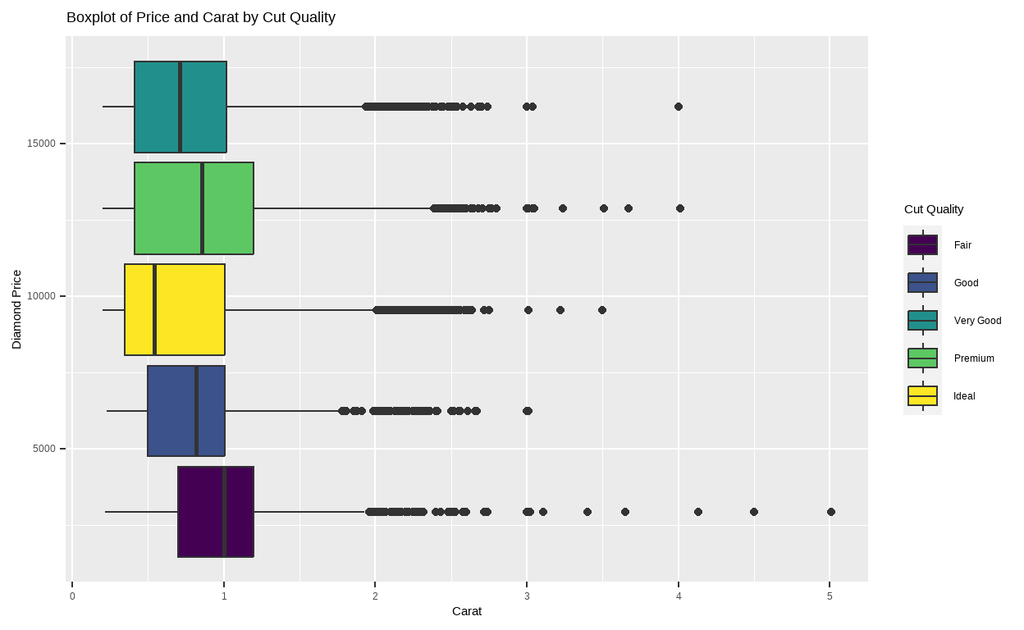

```r
diamonds%>%
  filter(x>0, y>0, z>0)%>%
  ggplot(aes(price, carat, fill = as.factor(cut))) + geom_boxplot()+
  labs(title = "Boxplot of Price and Carat by Cut Quality", x="Diamond Price", y="Carat", fill="Cut Quality")+
  coord_flip()
```

Before moving on to the next step, I want to check all the variable names in the dataset for validation and easily include them in the following sections.

```r
colnames(data)
```

```
 [1] "carat"   "cut"     "color"   "clarity" "depth"   "table"
 [7] "price"   "x"       "y"       "z"
```

## Correlations

The correlation plot below shows relationships between the dependent variable and independent variables. Variable x, y, and z have significantly high positive relations with each other at more than 0.96. All three variables are also highly correlated to the carat variable. In contrast, the relations between the dependent variable with the quality of cut and the diamond depth is very small negative relation. Therefore, I will remove variables x, y, and z to prevent multicollinearity.

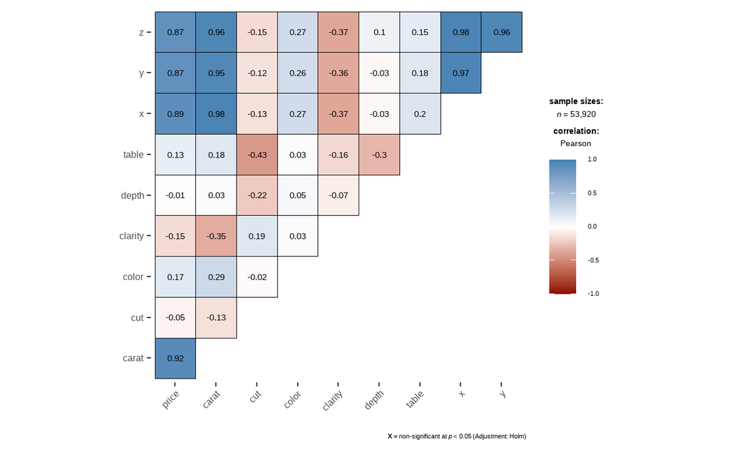

```r
# require library(ggstatsplot)
ggstatsplot::ggcorrmat(
  data = cor_data,
  type = "parametric", # parametric for Pearson, nonparametric for Spearman's correlation
  colors = c("darkred", "white", "steelblue") # change default colors
)
```

## Variance Inflation Factor (VIF)

Use variance inflation factor (VIF) to check that there are no two or more independent variables that predict each other.

```r
library(regclass)
VIF(lm(price~carat+cut+color+clarity+depth+table+x+y+z, data=data))
```

```
    carat       cut     color   clarity     depth     table         x
24.838037  1.483701  1.120603  1.230140  1.807764  1.580987 64.340380
        y         z
20.733711 29.940364
```

```r
VIF(lm(price~carat+cut+color+clarity+depth+table, data=data))
```

```
   carat      cut    color  clarity    depth    table
1.297629 1.482007 1.118782 1.200325 1.320529 1.576594
```

# Model selection

## Data division into train data and test data

```r
data2 <- data %>%
  dplyr::select(price,carat,cut,color,clarity,depth,table,x,y,z)

# split data for training data and test data
set.seed(789) # set seed to gain the same random pattern
train = data2 %>%
sample_frac(0.7)
test = data2 %>%
setdiff(train)
```

## Subsetting

The below charts illustrate the different values of $BIC$, $C_{p}$, $R^2$, and $adjusted R^2$, regarding the different number of variables in the model. According to the charts, adding depth and table variables have almost no contribution to the model. Hence, we will not consider adding depth and table variables to the model. In addition, adding the quality of diamond cut in the model appear small change to the model. So, I will compare the model containing 4 variables (carat, cut, color, and clarity) and 3 variables (carat, color, and clarity).

```r
# require library(leaps)
regfit_full = regsubsets(price ~ carat+cut+color+clarity+depth+table, data=train)
summary(regfit_full)
```

```
Subset selection object
Call: regsubsets.formula(price ~ carat + cut + color + clarity + depth +
    table, data = train)
6 Variables  (and intercept)
        Forced in Forced out
carat       FALSE      FALSE
cut         FALSE      FALSE
color       FALSE      FALSE
clarity     FALSE      FALSE
depth       FALSE      FALSE
table       FALSE      FALSE
1 subsets of each size up to 6
Selection Algorithm: exhaustive
         carat cut color clarity depth table
1  ( 1 ) "*"   " " " "   " "     " "   " "
2  ( 1 ) "*"   " " " "   "*"     " "   " "
3  ( 1 ) "*"   " " "*"   "*"     " "   " "
4  ( 1 ) "*"   "*" "*"   "*"     " "   " "
5  ( 1 ) "*"   "*" "*"   "*"     "*"   " "
6  ( 1 ) "*"   "*" "*"   "*"     "*"   "*"
```

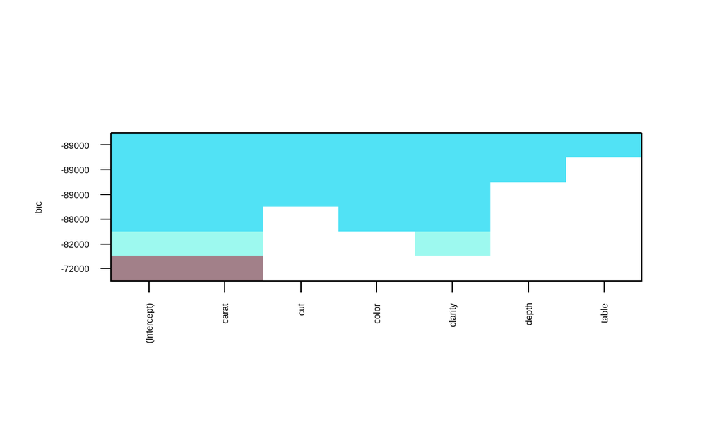

```r
plot(regfit_full, scale="bic", col=c("#51e2f5","#9df9ef", "#a28089"))
```

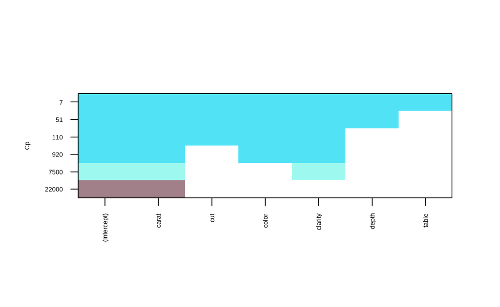

```r
plot(regfit_full, scale="Cp", col=c("#51e2f5","#9df9ef", "#a28089"))
```

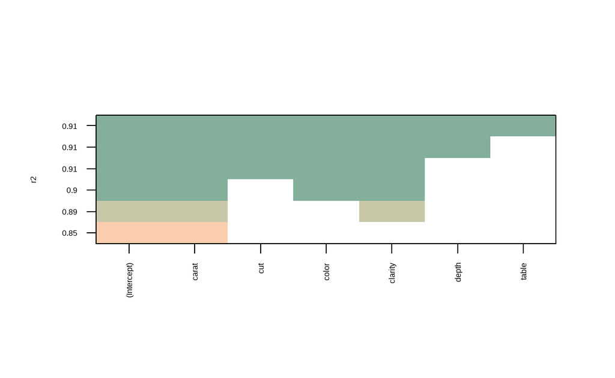

```r
plot(regfit_full, scale="r2", col=c("#83af9b","#c8c8a9", "#f9cdad"))
```

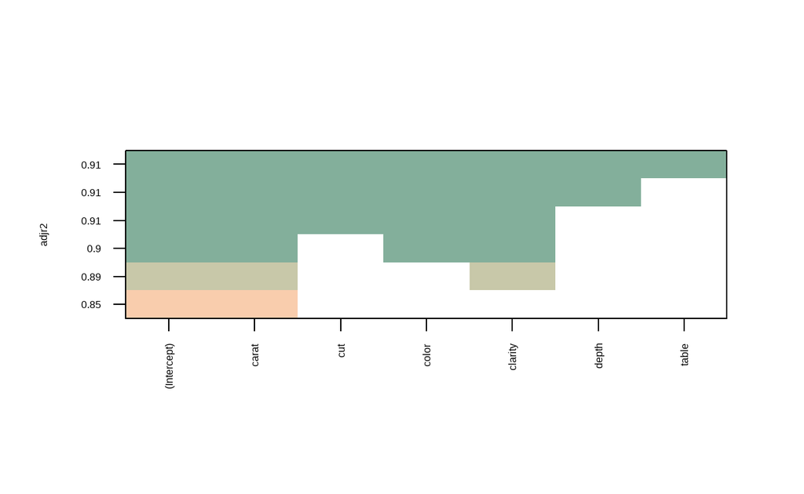

```r
plot(regfit_full, scale="adjr2", col=c("#83af9b","#c8c8a9", "#f9cdad"))
```

# Regression Model

**Model with 3 variables:**

**price = -4075.927 + 8746.191 x carat - 319.215 x color + 536.701 x clarity**

The estimated effect of carat on diamond price is 8746, the estimated effect of color is -319, and the estimated effect of clarity is 537.

```r
fit_lm3 <- lm(price ~ carat+color+clarity, data = train)
knitr::kable(fit_lm3 %>% broom::tidy())
```

| term | estimate | std.error | statistic | p.value |
| --- | --- | --- | --- | --- |
| (Intercept) | -4075.9265 | 25.598245 | -159.22680 | 0 |
| carat | 8746.1914 | 15.228347 | 574.33625 | 0 |
| color | -319.2149 | 3.972704 | -80.35203 | 0 |
| clarity | 536.7005 | 4.195932 | 127.90972 | 0 |

```r
knitr::kable(fit_lm3 %>% broom::augment()%>%slice(1:10))
```

| price | carat | color | clarity | .fitted | .resid | .hat | .sigma | .cooksd | .std.resid |
| --- | --- | --- | --- | --- | --- | --- | --- | --- | --- |
| 3985 | 0.93 | 5 | 3 | 4072.0588 | -87.05878 | 0.0000575 | 1241.250 | 1.00e-07 | -0.0701410 |
| 1046 | 0.31 | 4 | 7 | 1115.4371 | -69.43714 | 0.0001195 | 1241.250 | 1.00e-07 | -0.0559454 |
| 2959 | 0.70 | 3 | 5 | 3772.2656 | -813.26557 | 0.0000391 | 1241.243 | 4.20e-06 | -0.6552205 |
| 4876 | 1.01 | 5 | 3 | 4771.7541 | 104.24590 | 0.0000562 | 1241.250 | 1.00e-07 | 0.0839881 |
| 630 | 0.30 | 2 | 3 | -480.3972 | 1110.39722 | 0.0000935 | 1241.236 | 1.87e-05 | 0.8946337 |
| 462 | 0.26 | 5 | 5 | -714.4884 | 1176.48837 | 0.0000998 | 1241.235 | 2.24e-05 | 0.9478856 |
| 734 | 0.31 | 2 | 5 | 680.4658 | 53.53422 | 0.0000689 | 1241.250 | 0.00e+00 | 0.0431314 |
| 2936 | 0.74 | 3 | 4 | 3585.4127 | -649.41268 | 0.0000298 | 1241.245 | 2.00e-06 | -0.5232074 |
| 1294 | 0.44 | 1 | 5 | 2136.6855 | -842.68552 | 0.0000982 | 1241.242 | 1.13e-05 | -0.6789432 |
| 4201 | 0.91 | 5 | 4 | 4433.8355 | -232.83550 | 0.0000447 | 1241.249 | 4.00e-07 | -0.1875882 |

```r
knitr::kable(fit_lm3 %>% broom::glance())
```

| r.squared | adj.r.squared | sigma | statistic | p.value | df | logLik | AIC | BIC | deviance | df.residual | nobs |
| --- | --- | --- | --- | --- | --- | --- | --- | --- | --- | --- | --- |
| 0.9030269 | 0.9030192 | 1241.233 | 117146.7 | 0 | 3 | -322437.4 | 644884.8 | 644927.5 | 58144503086 | 37740 | 37744 |

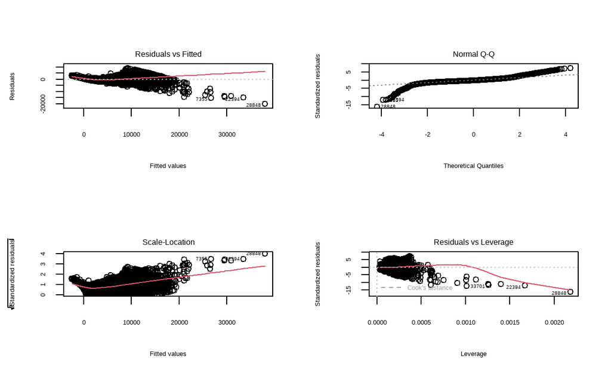

```r
res_function <- function(mod){
  par(mfrow = c(2, 2))
plot(mod)
}

res_function(fit_lm3)
```

**Model with 4 variables:**

The estimated effects of carat, cut, color, and clarity on diamond price are 8776, 165, -318, and 518, respectively. Hence, 1 unit increase in clarity will result in 518 dollars in diamond price.

```r
fit_lm4 <- lm(price ~ carat+cut+color+clarity, data = train)
knitr::kable(fit_lm4 %>% broom::tidy())
```

| term | estimate | std.error | statistic | p.value |
| --- | --- | --- | --- | --- |
| (Intercept) | -4674.9974 | 32.875915 | -142.20129 | 0 |
| carat | 8776.4296 | 15.103499 | 581.08586 | 0 |
| cut | 165.5113 | 5.791472 | 28.57845 | 0 |
| color | -318.8205 | 3.930478 | -81.11494 | 0 |
| clarity | 518.6481 | 4.199093 | 123.51433 | 0 |

```r
knitr::kable(fit_lm4 %>% broom::augment()%>%slice(1:10))
```

| price | carat | cut | color | clarity | .fitted | .resid | .hat | .sigma | .cooksd | .std.resid |
| --- | --- | --- | --- | --- | --- | --- | --- | --- | --- | --- |
| 3985 | 0.93 | 5 | 5 | 3 | 4276.4804 | -291.48038 | 0.0000915 | 1228.048 | 1.00e-06 | -0.2373664 |
| 1046 | 0.31 | 4 | 4 | 7 | 1062.9956 | -16.99564 | 0.0001218 | 1228.049 | 0.00e+00 | -0.0138406 |
| 2959 | 0.70 | 3 | 3 | 5 | 3601.8162 | -642.81617 | 0.0000627 | 1228.044 | 3.40e-06 | -0.5234685 |
| 4876 | 1.01 | 5 | 5 | 3 | 4978.5947 | -102.59474 | 0.0000909 | 1228.049 | 1.00e-07 | -0.0835478 |
| 630 | 0.30 | 1 | 2 | 3 | -958.2540 | 1588.25397 | 0.0002789 | 1228.022 | 9.33e-05 | 1.2935125 |
| 462 | 0.26 | 5 | 5 | 5 | -566.4312 | 1028.43123 | 0.0001176 | 1228.037 | 1.65e-05 | 0.8375118 |
| 734 | 0.31 | 4 | 2 | 5 | 663.3404 | 70.65957 | 0.0000691 | 1228.049 | 0.00e+00 | 0.0575408 |
| 2936 | 0.74 | 5 | 3 | 4 | 3765.2478 | -829.24785 | 0.0000560 | 1228.041 | 5.10e-06 | -0.6752843 |
| 1294 | 0.44 | 5 | 1 | 5 | 2288.6081 | -994.60807 | 0.0001169 | 1228.038 | 1.53e-05 | -0.8099673 |
| 4201 | 0.91 | 4 | 5 | 4 | 4454.0886 | -253.08858 | 0.0000450 | 1228.048 | 4.00e-07 | -0.2060974 |

```r
knitr::kable(fit_lm4 %>% broom::glance())
```

| r.squared | adj.r.squared | sigma | statistic | p.value | df | logLik | AIC | BIC | deviance | df.residual | nobs |
| --- | --- | --- | --- | --- | --- | --- | --- | --- | --- | --- | --- |
| 0.9050811 | 0.905071 | 1228.033 | 89963.22 | 0 | 4 | -322033.4 | 644078.7 | 644129.9 | 56912825216 | 37739 | 37744 |

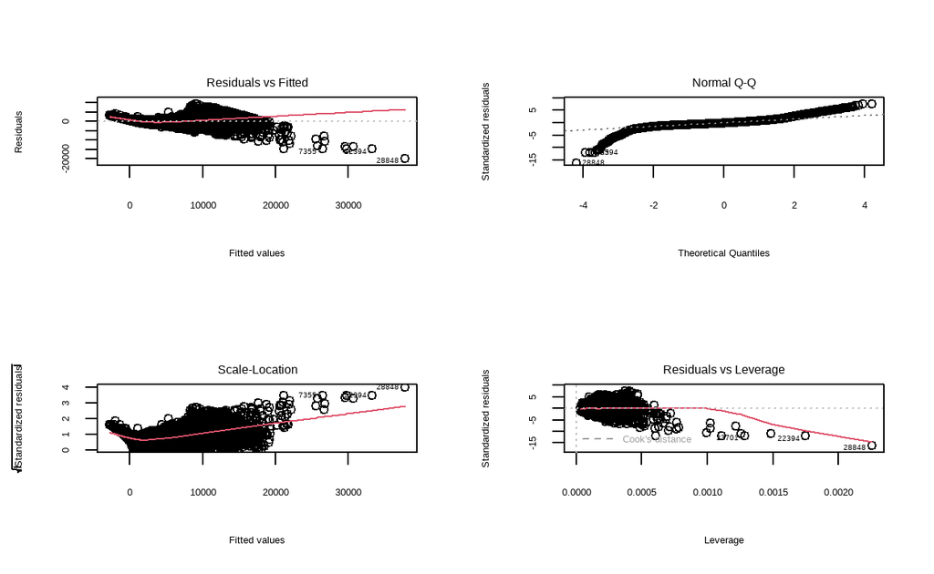

```r
res_function(fit_lm4)
```

# Conclusion